# Basics

## Some information on Data Science at Stack Exchange:

Return to main portfolio: https://xotofloyt.github.io/

This is a practice project that I performed during my studies in order to apply some analysis and visualization techniques to a data set.

My objective is to analyze the data and determine the data science topics most asked about by users of this site.

- This is a site that is dedicated to data science and any of the disciplines that contribute to data science in general, including python programming, machine learning, data wrangling, statistics...etc.
- This site also divides into several other sections including: Users Tags Unanswered questions
- we can use the tagging system to count the number of questions per topic
- Each questions contains indicators showing the number of views, number of answers, number of votes as well as tags which can help categorize the topics relevant to the question.

## We can see that some tables are of particular importance:

- The Posts table - which contains the posts, information about the users, number of votes, number of answers, number of comments,

# Extracting the necessary columns from the Posts table:

- We run the below querey in the DSSE

SELECT Id, PostTypeId, CreationDate, Score, ViewCount, Tags, AnswerCount, FavoriteCount FROM Posts WHERE PostTypeId = 1 AND YEAR(CreationDate) = 2019

## Exploring the Data:

- Reading the resultant CSV file into a dataframe:

```python
import pandas as pd

questions = pd.read_csv('2019_questions.csv', parse_dates=['CreationDate'])

questions.info()
```

```
<class 'pandas.core.frame.DataFrame'>
RangeIndex: 8839 entries, 0 to 8838
Data columns (total 7 columns):
Id               8839 non-null int64
CreationDate     8839 non-null datetime64[ns]
Score            8839 non-null int64
ViewCount        8839 non-null int64
Tags             8839 non-null object
AnswerCount      8839 non-null int64
FavoriteCount    1407 non-null float64
dtypes: datetime64[ns](1), float64(1), int64(4), object(1)
memory usage: 483.5+ KB
```

```python
questions['FavoriteCount'].value_counts(dropna=False)
```

```
NaN      7432
 1.0      953
 2.0      205
 0.0      175
 3.0       43
 4.0       12
 5.0        8
 6.0        4
 7.0        4
 11.0       1
 8.0        1
 16.0       1
Name: FavoriteCount, dtype: int64
```

- We can see that the FavoriteCount Column has 7432 missing values
- We can use boolean indexing to correct the values

## Cleaning The Data:

```python
questions.loc[questions['FavoriteCount'].isnull(), 'FavoriteCount'] = 0
questions['FavoriteCount'] = questions['FavoriteCount'].astype(int)
```

- Checking the data format:

```python
questions.head(3)
```

|  | Id | CreationDate | Score | ViewCount | Tags | AnswerCount | FavoriteCount |
| --- | --- | --- | --- | --- | --- | --- | --- |
| 0 | 44419 | 2019-01-23 09:21:13 | 1 | 21 | <machine-learning><data-mining> | 0 | 0 |
| 1 | 44420 | 2019-01-23 09:34:01 | 0 | 25 | <machine-learning><regression><linear-regressi... | 0 | 0 |
| 2 | 44423 | 2019-01-23 09:58:41 | 2 | 1651 | <python><time-series><forecast><forecasting> | 0 | 0 |

- Fixing the tags and turning them into lists of tags:

```python
questions['Tags'] = (questions['Tags'].str.replace("^<|>$", "").str.split("><"))

questions['Tags'].head(3)
```

```
0                      [machine-learning, data-mining]
1    [machine-learning, regression, linear-regressi...
2         [python, time-series, forecast, forecasting]
Name: Tags, dtype: object
```

- Confirming that we have the proper data types:

```python
questions.info()
```

```
<class 'pandas.core.frame.DataFrame'>
RangeIndex: 8839 entries, 0 to 8838
Data columns (total 7 columns):
Id               8839 non-null int64
CreationDate     8839 non-null datetime64[ns]
Score            8839 non-null int64
ViewCount        8839 non-null int64
Tags             8839 non-null object
AnswerCount      8839 non-null int64
FavoriteCount    8839 non-null int64
dtypes: datetime64[ns](1), int64(5), object(1)
memory usage: 483.5+ KB
```

## Counting Tag Use and Tag Views:

```python
tag_use = {}
tag_views = {}

for i in range(0, questions.shape[0]):
    tags = questions.iloc[i]['Tags']
    tag_view = questions.iloc[i]['ViewCount']
    for tag in tags:
        if tag in tag_use:
            tag_use[tag] +=1
        else:
            tag_use[tag] = 1

        if tag in tag_views:
            tag_views[tag] += tag_view
        else:
            tag_views[tag] = tag_view
```

```python
#converting dictionaries to dataframes:

tag_count = pd.DataFrame.from_dict(tag_use, orient='index')
tag_count.rename(columns={0: 'Count'}, inplace=True)

tag_view_counts = pd.DataFrame.from_dict(tag_views, orient='index')
tag_view_counts.rename(columns={0:'ViewCount'}, inplace=True)
```

```python
# Viewing a sample of Our resultant DataFrames:

tag_count.head()
```

|  | Count |
| --- | --- |
| ranking | 22 |
| libsvm | 1 |
| ann | 2 |
| pipelines | 17 |
| nlg | 9 |

```python
tag_view_counts.head()
```

|  | ViewCount |
| --- | --- |
| ranking | 1126 |
| libsvm | 54 |
| ann | 74 |
| pipelines | 2194 |
| nlg | 599 |

```python
# Sorting Our Data frames:

sorted_tag_counts = tag_count.sort_values(by='Count', ascending=True)
sorted_tag_views = tag_view_counts.sort_values(by='ViewCount', ascending=True)
```

```python
# Checking top values

sorted_tag_counts.tail()
```

|  | Count |
| --- | --- |
| keras | 935 |
| neural-network | 1055 |
| deep-learning | 1220 |
| python | 1814 |
| machine-learning | 2693 |

```python
sorted_tag_views.tail()
```

|  | ViewCount |
| --- | --- |
| pandas | 201787 |
| deep-learning | 233628 |
| keras | 268608 |
| machine-learning | 388499 |
| python | 537585 |

- plotting the resulting data frames:

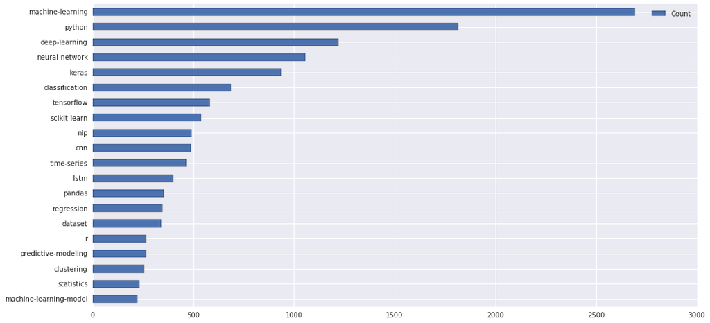

```python
import matplotlib.pyplot as plt
import seaborn as sns

%matplotlib inline

sorted_tag_counts.tail(20).plot(kind="barh", figsize=(16,8))
```

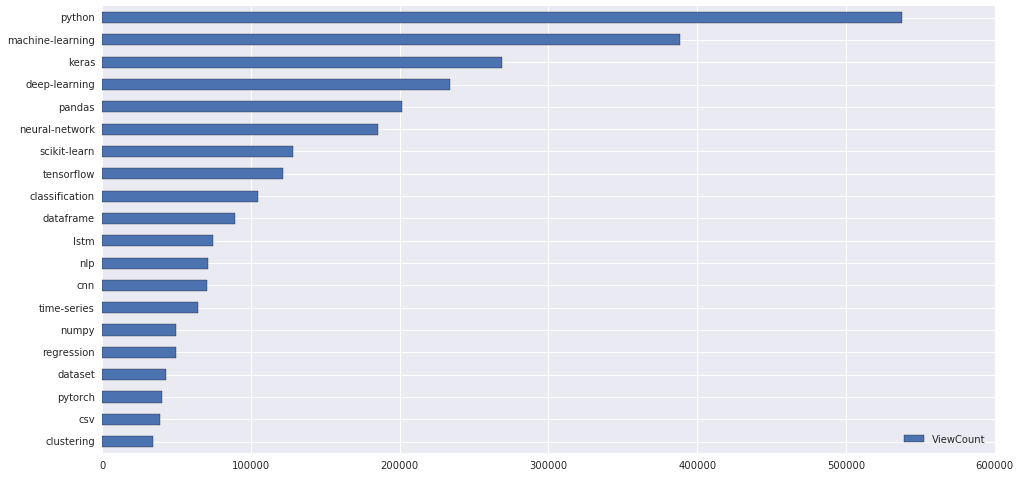

```python
sorted_tag_views.tail(20).plot(kind='barh', figsize=(16,8))
```

## Checking the relations between tags:

```
array([<matplotlib.axes._subplots.AxesSubplot object at 0x7fdc770fb358>],
      dtype=object)
```

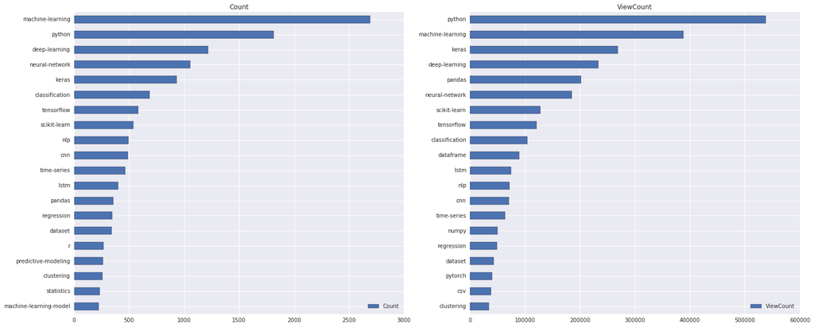

```python
fig, axes = plt.subplots(nrows=1, ncols=2)
fig.set_size_inches((24,10))
sorted_tag_counts.tail(20).plot(kind='barh', ax=axes[0], subplots=True)
sorted_tag_views.tail(20).plot(kind='barh', ax=axes[1], subplots=True)
```

- We can see that the most used and most viewed tags are mostly the same.
- Now we can check to see how many of the most viewed are in the most used tags:

```python
in_used = pd.merge(sorted_tag_counts.tail(20), sorted_tag_views.tail(20), how='left',
                   left_index=True, right_index=True)

in_used
```

|  | Count | ViewCount |
| --- | --- | --- |
| machine-learning-model | 224 | NaN |
| statistics | 234 | NaN |
| clustering | 257 | 33928.0 |
| predictive-modeling | 265 | NaN |
| r | 268 | NaN |
| dataset | 340 | 43151.0 |
| regression | 347 | 49451.0 |
| pandas | 354 | 201787.0 |
| lstm | 402 | 74458.0 |
| time-series | 466 | 64134.0 |
| cnn | 489 | 70349.0 |
| nlp | 493 | 71382.0 |
| scikit-learn | 540 | 128110.0 |
| tensorflow | 584 | 121369.0 |
| classification | 685 | 104457.0 |
| keras | 935 | 268608.0 |
| neural-network | 1055 | 185367.0 |
| deep-learning | 1220 | 233628.0 |
| python | 1814 | 537585.0 |
| machine-learning | 2693 | 388499.0 |

```python
in_used['ViewCount'].count()
```

```
16
```

- We ca see here that there are 16 shared values confirming our earlier findings.
- let us check how many of these tags are used together:

```python
qtags = list(tag_use.keys())

used_together = pd.DataFrame(index=qtags, columns=qtags)

used_together.fillna(0, inplace=True)

for tags in questions['Tags']:
    used_together.loc[tags, tags] +=1


relations_most_used = used_together.loc[in_used.index, in_used.index]
```

```python
relations_most_used
```

|  | machine-learning-model | statistics | clustering | predictive-modeling | r | dataset | regression | pandas | lstm | time-series | cnn | nlp | scikit-learn | tensorflow | classification | keras | neural-network | deep-learning | python | machine-learning |
| --- | --- | --- | --- | --- | --- | --- | --- | --- | --- | --- | --- | --- | --- | --- | --- | --- | --- | --- | --- | --- |
| machine-learning-model | 224 | 3 | 3 | 21 | 7 | 12 | 8 | 4 | 5 | 7 | 4 | 4 | 18 | 9 | 21 | 17 | 10 | 19 | 37 | 139 |
| statistics | 3 | 234 | 3 | 16 | 16 | 17 | 16 | 3 | 1 | 22 | 1 | 3 | 6 | 0 | 19 | 3 | 11 | 12 | 35 | 89 |
| clustering | 3 | 3 | 257 | 0 | 16 | 5 | 2 | 5 | 3 | 20 | 0 | 9 | 24 | 0 | 12 | 0 | 8 | 2 | 45 | 61 |
| predictive-modeling | 21 | 16 | 0 | 265 | 13 | 7 | 28 | 4 | 13 | 31 | 6 | 1 | 12 | 6 | 27 | 11 | 13 | 32 | 35 | 123 |
| r | 7 | 16 | 16 | 13 | 268 | 6 | 10 | 2 | 3 | 22 | 2 | 4 | 1 | 1 | 10 | 10 | 9 | 5 | 24 | 63 |
| dataset | 12 | 17 | 5 | 7 | 6 | 340 | 6 | 14 | 7 | 6 | 11 | 11 | 9 | 9 | 28 | 13 | 20 | 32 | 53 | 99 |
| regression | 8 | 16 | 2 | 28 | 10 | 6 | 347 | 6 | 11 | 24 | 6 | 2 | 37 | 9 | 34 | 31 | 42 | 21 | 59 | 119 |
| pandas | 4 | 3 | 5 | 4 | 2 | 14 | 6 | 354 | 7 | 19 | 1 | 3 | 37 | 3 | 3 | 3 | 1 | 1 | 244 | 62 |
| lstm | 5 | 1 | 3 | 13 | 3 | 7 | 11 | 7 | 402 | 87 | 24 | 19 | 2 | 43 | 20 | 133 | 69 | 103 | 61 | 71 |
| time-series | 7 | 22 | 20 | 31 | 22 | 6 | 24 | 19 | 87 | 466 | 8 | 0 | 12 | 9 | 25 | 51 | 33 | 44 | 105 | 131 |
| cnn | 4 | 1 | 0 | 6 | 2 | 11 | 6 | 1 | 24 | 8 | 489 | 7 | 0 | 57 | 20 | 116 | 118 | 160 | 62 | 124 |
| nlp | 4 | 3 | 9 | 1 | 4 | 11 | 2 | 3 | 19 | 0 | 7 | 493 | 12 | 11 | 35 | 23 | 24 | 72 | 71 | 113 |
| scikit-learn | 18 | 6 | 24 | 12 | 1 | 9 | 37 | 37 | 2 | 12 | 0 | 12 | 540 | 15 | 47 | 34 | 24 | 16 | 235 | 188 |
| tensorflow | 9 | 0 | 0 | 6 | 1 | 9 | 9 | 3 | 43 | 9 | 57 | 11 | 15 | 584 | 20 | 256 | 108 | 136 | 167 | 106 |
| classification | 21 | 19 | 12 | 27 | 10 | 28 | 34 | 3 | 20 | 25 | 20 | 35 | 47 | 20 | 685 | 58 | 65 | 59 | 98 | 259 |
| keras | 17 | 3 | 0 | 11 | 10 | 13 | 31 | 3 | 133 | 51 | 116 | 23 | 34 | 256 | 58 | 935 | 235 | 247 | 280 | 195 |
| neural-network | 10 | 11 | 8 | 13 | 9 | 20 | 42 | 1 | 69 | 33 | 118 | 24 | 24 | 108 | 65 | 235 | 1055 | 305 | 137 | 366 |
| deep-learning | 19 | 12 | 2 | 32 | 5 | 32 | 21 | 1 | 103 | 44 | 160 | 72 | 16 | 136 | 59 | 247 | 305 | 1220 | 160 | 429 |
| python | 37 | 35 | 45 | 35 | 24 | 53 | 59 | 244 | 61 | 105 | 62 | 71 | 235 | 167 | 98 | 280 | 137 | 160 | 1814 | 499 |
| machine-learning | 139 | 89 | 61 | 123 | 63 | 99 | 119 | 62 | 71 | 131 | 124 | 113 | 188 | 106 | 259 | 195 | 366 | 429 | 499 | 2693 |

## Enter Domain Knowledge

Creating a topic related to this should be considerd.

## Just a Fad?

We will now read in a file containing all questions ever asked:

```python
all_questions = pd.read_csv('all_questions.csv', parse_dates=['CreationDate'])

all_questions['Tags'] = all_questions['Tags'].str.replace('^<|>$', '').str.split('><')
```

We will add a deeplearning column to "all_questions" to indicate if the question relates to deep learning:

```python
def deeplearningclassify(tags):
    for tag in tags:
        if tag in ['machine-learning', 'deep-learning', 'neural-network', 'keras', 'tensorflow', 'scikit-learn']:
            return 1
    return 0
```

```python
all_questions['DeepLearning'] = all_questions['Tags'].apply(deeplearningclassify)
```

```python
all_questions['Year'] = all_questions['CreationDate'].dt.year
```

Now we will create a dataframe which sums the total number of deep learning questions per year. We will limit our data set to the years 2015 to 2019 as the years 2014 and 2020 have partial data.

```python
y_dl_q = all_questions.groupby('Year')['DeepLearning'].sum()
```

```python
y_dl_q = y_dl_q.reset_index()
```

```python
y_dl_q = y_dl_q[(y_dl_q['Year'] > 2014) & (y_dl_q['Year'] < 2020)]
```

```python
y_dl_q
```

|  | Year | DeepLearning |
| --- | --- | --- |
| 1 | 2015 | 483 |
| 2 | 2016 | 1036 |
| 3 | 2017 | 1649 |
| 4 | 2018 | 3264 |
| 5 | 2019 | 4892 |

Now to calculate the total questions per year:

```python
y_tq = all_questions.groupby('Year')['Id'].count()
```

```python
y_tq = y_tq.reset_index()
```

```python
y_tq = y_tq[(y_tq['Year'] > 2014) & (y_tq['Year'] < 2020)]
```

```python
y_tq
```

|  | Year | Id |
| --- | --- | --- |
| 1 | 2015 | 1167 |
| 2 | 2016 | 2146 |
| 3 | 2017 | 2957 |
| 4 | 2018 | 5475 |
| 5 | 2019 | 8810 |

mergin the 2 dataframes:

```python
total_questions_py = pd.merge(left=y_dl_q, right=y_tq, on='Year')
```

```python
total_questions_py.rename(columns={'Id':'TotalQ'}, inplace=True)
```

```python
total_questions_py['DeepLearningRate']=(total_questions_py['DeepLearning']
                                        /total_questions_py['TotalQ'])
```

```python
total_questions_py
```

|  | Year | DeepLearning | TotalQ | DeepLearningRate |
| --- | --- | --- | --- | --- |
| 0 | 2015 | 483 | 1167 | 0.413882 |
| 1 | 2016 | 1036 | 2146 | 0.482759 |
| 2 | 2017 | 1649 | 2957 | 0.557660 |
| 3 | 2018 | 3264 | 5475 | 0.596164 |
| 4 | 2019 | 4892 | 8810 | 0.555278 |

Plotting the results on the graph

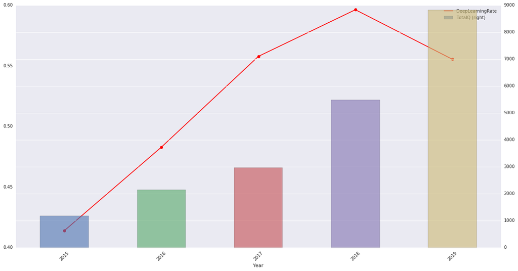

```python
tqpy = total_questions_py.copy()

tqpy['Year'] = tqpy['Year'].astype(str)

ax1 = tqpy.plot(x='Year', y='DeepLearningRate',
                             kind='line', linestyle='-', marker='o',
                              color='red', figsize=(20,10))

ax2 = tqpy.plot(x='Year', y='TotalQ',
               kind='bar', ax=ax1, secondary_y=True,
               alpha=0.6, rot=45)
```

- we can see that deep learning as a percentage of questions asked, kept rising and peaked in popularity in the year 2018 but dropped in proportion slightly in 2019. This does not mean that it is not a popular topic anymore.